## Background

Stephanie[^1] is a student that will be starting school at BYU-Idaho next semester. Here is a copy of the email request for information that she sent.

“Hi. My name is Stephanie. I would like to learn about what housing options I have for living at BYU-Idaho next semester. It will be my first semester there, so I would like to find something that is close to campus and around $300 a month in rent. I’m not too picky on roomates, but I would like somewhere that has a lot of people around so I can get to know as many people as possible. Thanks in advance!”

Use the data from the [BYU-Idaho Housing Website](https://web.byui.edu/tis/search) to prepare an Analysis that will answer Stephanie’s questions and give her some recommendations on a few apartments that best meet her criterions above. However, also be sure to demonstrate all of her options to her.

For your convenience, the first three observations of a dataset pulled from the BYUI website are shown in the following table. There are a total of 122 observations in the dataset.

```r
datatable(Rent, options=list(lengthMenu = c(3,10,30)))
```

|  | Apartment | Gender | Address | Phone | Cost | CostHigh | Residents | ParkingStalls | Deposit | UtilityDeposit | FloorPlans | Website | Latitude | Longitude | Miles2Campus | WalkMinutes | Description |
| --- | --- | --- | --- | --- | --- | --- | --- | --- | --- | --- | --- | --- | --- | --- | --- | --- | --- |
| 1 | ABBY LANE MANOR | F | 437 S 4TH W | (208) 359-3687 | 1035 | 1060 | 42 | 38 | 100 | 0 | 3 | www.abbylaneapartments.com | 43.8169418 | -111.7952062 | 0.745647284 | 16 | We are a small women's complex offering private rooms and quaint living. Many students enjoy our advantages enough that they stay with us until graduation. We are sure you would like staying with us! … |
| 2 | ABODE DUPLEX | M | 224 E 2ND S | (912) 399-1107 | 980 | 980 | 6 | 3 | 100 | 0 | 1 | sites.google.com/site/robertspencerbrown/abodehouse | 43.8218153 | -111.7771495 | 0.186411821 | 4 | This cozy little apartment is located only one block from campus. There are a lot of freebies for the price. All utilities are included, there is a free-to-use, in-apartment washer and dryer, free WiF… |
| 3 | ABRI APARTMENTS - MEN | M | 220 E 1ST S | 2084177223 | 1420 | 1445 | 138 | 216 | 150 | 0 | 3 | www.liveabri.com | 43.8239342 | -111.7773062 | 0.310686368 | 8 | 24 hour special $100 off! Look no further than the Abri, Rexburg's newest student housing community. Currently leasing women's spots for fall '17, &amp; men's for winter '18. From upscale, modern fini… |
| 4 | ABRI APARTMENTS - WOMEN | F | 220 E 1ST S | (208) 417-7223 | 1445 | 1495 | 150 | 216 | 150 | 0 | 3 | www.liveabri.com | 43.8239342 | -111.7773062 | 0.310686368 | 8 | $100 OFF SPECIAL! Look no further than the Abri, Rexburg's newest student housing community. Currently leasing women's spots for fall '17, &amp; men's for winter '18. From upscale, modern finishes, to… |
| 5 | ALBION APARTMENT | F | 231 W 2ND S | (801) 856-0732 | 1062.5 | 1150 | 5 | 4 | 100 | 0 | 3 |  | 43.8218385 | -111.7906463 | 0.186411821 | 4 | Cute, newly painted basement apartment across the street from Porter Park and 1.5 blocks from the Hart building. Utilities and Internet are free. Washer and Dryer included in the Apartment. There are … |
| 6 | ALEXANDER APARTMENT | F | 276 W 3RD S | 208-995-8543 | 972.5 | 1115 | 22 | 18 | 100 | 0 | 10 | www.alexanderapartments.wordpress.com | 43.8197811 | -111.7918951 | 0.434960916 | 8 | We are also signing for Fall and Winter 2017. Get $25 off per semester for signing 2 consecutive semesters. No application fee or parking fee and get $40 in quarters for laundry each semester. |
| 7 | ALLDREDGE HOUSE | F | 243 S 1ST E | 208-206-4697 | 1045 | 1095 | 8 | 8 | 150 | 0 | 3 |  | 43.82073 | -111.780478 | 0.186411821 | 5 | Hurry quick! Come make ALLDREDGE HOUSE your home away from home! Located directly across the street from the Clarke and Kirkham Buildings and only a few blocks away from down town. Great ward with the… |
| 8 | ALLEN RIDGE APARTMENTS | M | 57 S CENTER ST | (801) 864-1708 | 890 | 890 | 17 | 9 | 100 | 0 | 1 | allenridge.blogspot.com | 43.824663 | -111.7835934 | 0.310686368 | 6 | The best kept housing secret at BYU-Idaho. Small complex (only 17 tenants), but large living areas and rooms. Private, but in the best location in town - central to campus, shopping, and great activit… |
| 9 | ALLEN'S SUNRISE VILLAGE - MEN | M | 48 W 2ND S | 356-3995 | 1000 | 1075 | 138 | 133 | 100 | 0 | 3 | www.sunrisevillageapts.com | 43.821866 | -111.7852097 | 0.062137274 | 1 | Allen's Sunrise Village offers housing for both men and women! We are well-known for our friendliness,low prices,great location,fantastically reliable OPTIX internet,friendly residents and amazing man… |
| 10 | ALLEN'S SUNRISE VILLAGE - WOMEN | F | 48 W 2ND S | 208-356-3995 | 1000 | 1075 | 144 | 133 | 100 | 0 | 3 | www.sunrisevillageapts.com | 43.82186 | -111.785197 | 0.062137274 | 1 | We offer housing for both men and women! We are well-known for our friendliness, new modern remodel, low prices, great location, our fantastically reliable OPTIX internet and amazing managers. You'll … |

[output cut: 112 more lines]

## Student Housing Costs

In response to Stephanie’s freshman dilemma, “Which apartment complex is the best apartment that is only $300 a month, close to campus, and has an active social life?”, the following research has been proposed. All student housing (that is approved for women) has had it’s price, location, and amount of people analyzed to see which option would be the best for Stephanie.

My hypothesis is that the best apartment that fits her qualificatinos is Snow View Apartments. I believe it falls in the $300 a month price range, is really close to campus, and has quite a few people.

# Location analysis

```
##                          apartment   distance
## 1  ALLEN'S SUNRISE VILLAGE - WOMEN 0.06213727
## 2                      BIRCH PLAZA 0.06213727
## 3                     BIRCH WOOD I 0.06213727
## 4                   CARRIAGE HOUSE 0.06213727
## 5         KENSINGTON MANOR - WOMEN 0.06213727
## 6               NORTHPOINT - WOMEN 0.06213727
## 7                    BAYSIDE MANOR 0.12427455
## 8                 IVY, THE - Women 0.12427455
## 9              SNOWVIEW APARTMENTS 0.12427455
## 10                   WEBSTER HOUSE 0.12427455
## 11                ALBION APARTMENT 0.18641182
## 12                ALLDREDGE HOUSE  0.18641182
## 13                    AT THE GROVE 0.18641182
## 14            DAVENPORT APARTMENTS 0.18641182
```

[output cut: 42 more lines]

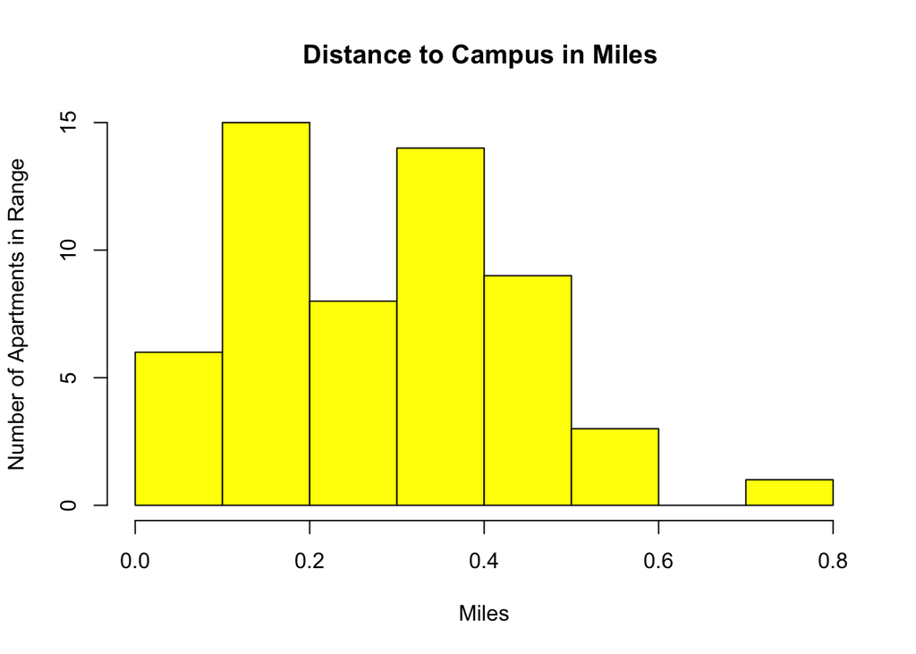